# HW2:Wine Features

Author

Jacob Plax

Published

February 3, 2025

**Abstract:**

This is a technical blog post of **both** an HTML file *and* [.qmd file](https://raw.githubusercontent.com/JacobHack/DATA505HW/refs/heads/main/src/wine_features.qmd) hosted on GitHub pages.

# Setup

**Step Up Code:**

```r
library(tidyverse)
library(caret)
library(fastDummies)
wine <- readRDS(gzcon(url("https://github.com/cd-public/D505/raw/master/dat/wine.rds")))
```

# Feature Engineering

We begin by engineering an number of features.

1. Create a total of 10 features (including points).
2. Remove all rows with a missing value.
3. Ensure only log(price) and engineering features are the only columns that remain in the `wino` dataframe.

```r
wino <- wine %>%
  mutate(lprice=log(price)) %>%
  mutate(country = fct_lump(country, 4)) %>%
  mutate(variety = fct_lump(variety, 4)) %>%
  select(lprice, points, country, variety) %>%
  drop_na()
head(wino)
```

```
# A tibble: 6 × 4
  lprice points country variety
   <dbl>  <dbl> <fct>   <fct>
1   2.71     87 Other   Other
2   2.64     87 US      Other
3   2.56     87 US      Other
4   4.17     87 US      Pinot Noir
5   2.71     87 Spain   Other
6   2.77     87 Italy   Other
```

**Explanataion:**

1. We create a new column `lprice` which is the logarithm of the `price` column.
2. We lump the `country` column into the top 4 most common countries and group the rest into “Other”.
3. We lump the `variety` column into the top 4 most common varieties and group the rest into “Other”.
4. We select only the `lprice`, `points`, `country`, and `variety` columns.
5. We remove any rows that contain missing values.
6. Finally, we display the first few rows of the resulting `wino` dataframe using the `head` function.

# Caret

We now use a train/test split to evaluate the features.

1. Use the Caret library to partition the wino dataframe into an 80/20 split.
2. Run a linear regression with bootstrap resampling.
3. Report RMSE on the test partition of the data.

```r
set.seed(123)

trainIndex <- createDataPartition(wino$lprice, p = 0.8, list = FALSE)
wino_train <- wino[trainIndex, ]
wino_test <- wino[-trainIndex, ]

train_control <- trainControl(method = "boot", number = 100)
model <- train(lprice ~ ., data = wino_train, method = "lm", trControl = train_control)

predictions <- predict(model, wino_test)
rmse <- sqrt(mean((wino_test$lprice - predictions)^2))
rmse
```

```
[1] 0.4902949
```

**Explanation**

1. We set a seed for reproducibility.
2. We create a training index that partitions the `wino` dataframe into an 80/20 split.
3. We create training and testing datasets using the partition index.
4. We define the training control using bootstrap resampling with 100 iterations.
5. We train a linear regression model using the training data and the defined training control.
6. We make predictions on the test data using the trained model.
7. We calculate the Root Mean Squared Error (RMSE) to evaluate the model’s performance on the test data.

# Variable selection

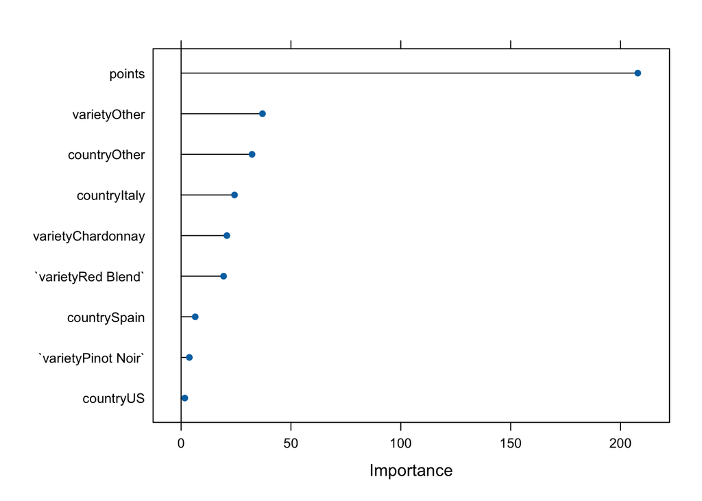

```r
plot(varImp(model, scale = FALSE))
```

**Explanation**

1. We use the `varImp` function from the `caret` package to calculate the importance of each feature in the model.
2. We plot the variable importance using the `plot` function, which helps us visualize the significance of each feature in predicting the target variable `lprice`.